# < 국내 장애인의 현황과 복지 현황 > - 1조

#### - 전반적 '장애인' 관련 현황

#### - 교육, 고용, 인식, 장애인 학대 관련한 현황 + 관련 복지/정책/지원

## [ 전반적 '장애인' 관련 현황 ] (허채범)

### 0. 모듈 및 함수

### 1. 장애인 전체 현황(2015-2021, 7개년)

### 2. 장애인 유형별 현황 (2019-2021, 21년도와 유사)

### 3. 장애인 연령별 현황 (2019-2021, 3개년)

### 0. 모듈 및 함수

```python
# 모듈 로딩
import pymysql
import pandas as pd
import matplotlib.pyplot as plt
import seaborn as sns
from IPython.display import Image
import platform
import numpy as np
import seaborn as sns

# 한글 폰트
if(platform.system() == 'Windows'):
    plt.rc('font', family='Malgun Gothic')
else:
    plt.rc('font', family='AppleGothic')
```

```python
# 조회하여 줄단위로 읽기
def mysql1(qqq):
    conn = pymysql.connect(host='localhost', user='root', password='fkfk2rj2@!##H',
                            db='teamproject', charset='utf8')
    curs = conn.cursor()

    curs.execute(qqq)
    rows = curs.fetchall()
#     for row in rows:
#         print(row)
    conn.commit()
    conn.close()
    return list(rows)
```

```python
# 쿼리문들

# 전국_장애인수_7개년
query1 = """
select * from reg_7_year;
"""
# 전국_유형별_3개년
query2 = """
select 장애유형, `심한장애(계)`, `심하지 않은 장애(계)` from reg_2021;
"""

# 전국_유형별_3개년_남
query3 = """
select 장애유형, `합계(남)` from reg_2019;
"""

query4 = """
select `합계(남)` from reg_2020;
"""

query5 = """
select `합계(남)` from reg_2021;
"""

# 전국_유형별_3개년_여
query6 = """
select 장애유형, `합계(여)` from reg_2019;
"""

query7 = """
select `합계(여)` from reg_2020;
"""

query8 = """
select `합계(여)` from reg_2021;
"""

# 연령별
# 1) 1살-8살 (학창시절 이전)  &  2019-21 (3개년)
query11 = """
select a.연도, sum(a.`합계(계)`) as `1-8살(명)`
from 전국_유형_연령 as a
where (나이 >= 1 and 나이 <= 8)
group by 연도;
"""

# 2) 9살-24살 (학창시절)  &  2019-21 (3개년)
query12 = """
select sum(a.`합계(계)`) as `9-19살(명)`
from 전국_유형_연령 as a
where (나이 >= 9 and 나이 <= 24)
group by 연도;
"""

# 3) 25살(20대 중반) - 49살  &  2019-21 (3개년)
query13 = """
select sum(a.`합계(계)`) as `25-49살(명)`
from 전국_유형_연령 as a
where (나이 >= 25 and 나이 <= 49)
group by 연도;
"""

# 4) 50대 이후  &  2019-21 (3개년)
query14 = """
select sum(a.`합계(계)`) as `50살 이후(명)`
from 전국_유형_연령 as a
where (나이 >= 50 )
group by 연도;
"""
```

```python
def sevenYear_graph():
    sevenYear = mysql1(query1)

    year = []
    dis = []
    pop = []
    for i in range(len(sevenYear)):
        year.append(sevenYear[i][0])
        dis.append(sevenYear[i][1])
        pop.append(sevenYear[i][2])

    x = year
    y1 = dis
    y2 = pop

    # 장애인수 증가 그래프
    fig, axes = plt.subplots(1,2, figsize=(20,10))
    plt.subplot(1,2,1)
    # plt.figure(figsize=(18,6))
    plt.plot(x,y1, 'blue', marker='s', label='장애인증가수(명)')
    plt.xticks(x, fontsize =15)
    plt.yticks(fontsize =15)

    plt.ylabel('증가수', fontsize='20')
    plt.xlabel('연도', fontsize='20')
    plt.legend(loc = 2, fontsize=15)
    plt.title('< 장애인구 변화 추이 7개년(2015-2021년) >', fontsize='20')
    plt.style.use("ggplot")

    # 전국인구수 증가 그래프
    plt.subplot(1,2,2)
    plt.plot(x,y2, 'red', marker='s', label='전국인구증가수(명)')
    plt.xticks(x, fontsize =15)
    plt.yticks(fontsize =15)

    plt.ylabel('증가수', fontsize='20')
    plt.xlabel('연도', fontsize='20')
    plt.legend(loc = 2, fontsize=15)
    plt.title('< 전국인구 변화 추이 7개년(2015-2021년) >', fontsize='20')
    plt.style.use("ggplot")

    plt.show()
```

```python
def lowHigh_df():
    lowHigh = mysql1(query2)

    assort = []
    dis = []
    weak = []

    for i in range(len(lowHigh)):
        assort.append(lowHigh[i][0])
        dis.append(lowHigh[i][1])
        weak.append(lowHigh[i][2])

    x = assort
    y1 = dis
    y2 = weak

    data1 = pd.Series(y1)
    data2 = pd.Series(y2)

    lowHigh_df = pd.concat([data1, data2], axis=1).T
    lowHigh_df.columns = x

    inxName=['심한 장애', '심하지 않은 장애']

    lowHigh_df.index = inxName
    lowHigh_df = lowHigh_df.T
    return lowHigh_df
```

```python
def age_graph_data():

    year = []
    age1 = []
    age2 = []
    age3 = []
    age4 = []

    # 1살-8살
    age_graph = mysql1(query11)
    age1.append(int(age_graph[0][1]))
    age2.append(int(age_graph[1][1]))
    age3.append(int(age_graph[2][1]))

    # 9살-24살
    age_graph = mysql1(query12)
    age1.append(int(age_graph[0][0]))
    age2.append(int(age_graph[1][0]))
    age3.append(int(age_graph[2][0]))

    # 25살-49살
    age_graph = mysql1(query13)
    age1.append(int(age_graph[0][0]))
    age2.append(int(age_graph[1][0]))
    age3.append(int(age_graph[2][0]))

    # 50살 이상
    age_graph = mysql1(query14)
    age1.append(int(age_graph[0][0]))
    age2.append(int(age_graph[1][0]))
    age3.append(int(age_graph[2][0]))
```

```python
def age_graph_draw():
    # 색깔 리스트 만들기
    colors = sns.color_palette("muted", 4)

    # 원그래프 그리기
    fig, axes = plt.subplots(1,3, figsize=(20,10))
    plt.subplot(1,3,1)
    labels = ['1-8살', '9-24살', '25-49살', '50살 이상']
    # plt.figure(figsize=(10,8))
    plt.pie(age1, labels=labels, colors = colors, autopct='%.1f%%', textprops={'fontsize':16}, explode=[0, 0, 0, 0.1])
    plt.title('총 장애인수 대비 연령대별 비율(2019)')
    plt.legend(loc = 2, fontsize=13, shadow=True, facecolor='white')

    plt.subplot(1,3,2)
    labels = ['1-8살', '9-24살', '25-49살', '50살 이상']
    # plt.figure(figsize=(10,8))
    plt.pie(age2, labels=labels, colors = colors, autopct='%.1f%%', textprops={'fontsize':16}, explode=[0, 0, 0, 0.1])
    plt.title('총 장애인수 대비 연령대별 비율(2020)')
#     plt.legend(loc = 2, fontsize=13, shadow=True, facecolor='white')

    plt.subplot(1,3,3)
    labels = ['1-8살', '9-24살', '25-49살', '50살 이상']
    # plt.figure(figsize=(10,8))
    plt.pie(age3, labels=labels, colors = colors, autopct='%.1f%%', textprops={'fontsize':16}, explode=[0, 0, 0, 0.1])
    plt.title('총 장애인수 대비 연령대별 비율(2021)')
#     plt.legend(loc = 2, fontsize=13, shadow=True, facecolor='white')

    plt.show()
```

### ** '장애인'의 정의 (장애인복지법 2조 1항)

#### : 신체적ㆍ정신적 장애로 오랫동안 일상생활이나 사회생활에서 상당한 제약을 받는 자를 말한다.

### 1. 장애인 전체 현황(2015-2021, 7개년)

### 2) 장애인 변화 현황 (7개년)

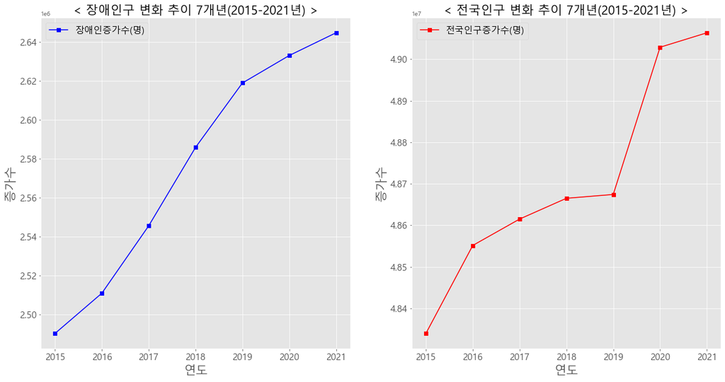

```python
sevenYear_graph()
```

### 2. 장애인 유형별 현황 (2019-2021, 3개년)

[figure not shown]

```python
Image('img/poster.png')
```

- 01(정신적), 02(뇌병변), 09(청각장애), 13(지적장애), 16(시각장애), 17(언어장애), 17(안면기형장애), 22(자폐)

### * 법적 장애인 유형은 15가지로 구분 (장애인복지법 시행령 [별표1])

- 지체, 시각, 청각, 언어, 지적
- 뇌병변, 정신, 자폐성, 신장, 심장
- 호흡기, 간, 안면, 장루.요루, 뇌전증

### [ 정신적 관련 ]

- 지적장애인 : 정신 발육이 항구적으로 지체되어 지적 능력의 발달이 불충분하거나 불완전
- 자폐성장애인 : 언어·신체표현·자기조절·사회적응 기능 및 능력의 장애
- 정신장애인 : 감정조절ㆍ행동ㆍ사고 기능 및 능력의 장애
  - 조현병, 재발성 우울장애, 강박장애, 투렛

### 1) 전국 유형별 (2021)

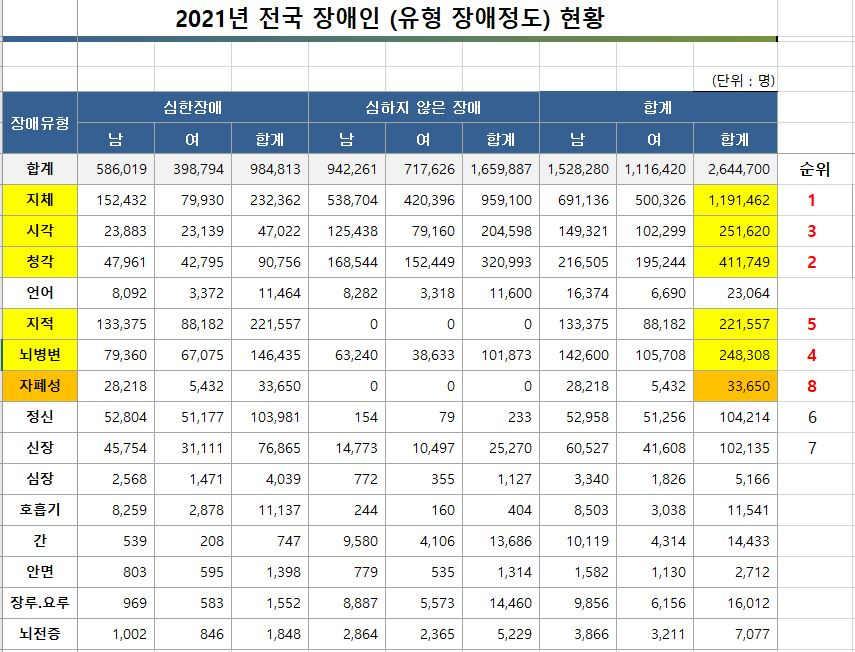

```python
Image('img/reg2021.jpg')
```

### 2) 유형별 경중판단 -> 2021년 유형별 장애인수 합계

```python
lowHigh_df()
```

|  | 심한 장애 | 심하지 않은 장애 |
| --- | --- | --- |
| 지체 | 232,362 | 959,100 |
| 시각 | 47,022 | 204,598 |
| 청각 | 90,756 | 320,993 |
| 언어 | 11,464 | 11,600 |
| 지적 | 221,557 | 0 |
| 뇌병변 | 146,435 | 101,873 |
| 자폐성 | 33,650 | 0 |
| 정신 | 103,981 | 233 |
| 신장 | 76,865 | 25,270 |
| 심장 | 4,039 | 1,127 |
| 호흡기 | 11,137 | 404 |
| 간 | 747 | 13,686 |
| 안면 | 1,398 | 1,314 |
| 장루.요루 | 1,552 | 14,460 |
| 뇌전증 | 1,848 | 5,229 |

- 19,20,21 같은 구성
- (신장제외) 신체적 vs. 정신적

### 3. 장애인 연령별 현황 (2019-2021, 3개년)

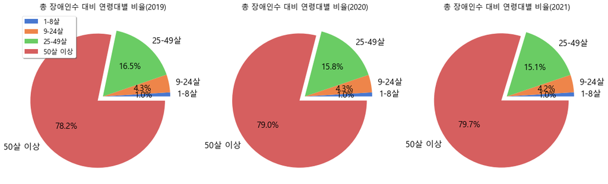

```python
age_graph_data()
age_graph_draw()
```

### 힘들었던 점

- db설계
- data를 원하는 대로 편집하기가 힘들었다